# European_Soccer_Predictions

Tien_Dinh

2022-06-06

## Exploring the data

My dataset is called: European Soccer Database 25k+ matches, players & teams attributes for European Professional Football. The dataset is from Kaggle.com: https://www.kaggle.com/datasets/hugomathien/soccer

This is the EA sport FIFA soccer database for data analysis for machine learning. The creator’s name is HUGO MATHIEN. We don’t know much about the guy’s history, but we do know that he is a dedicated soccer fan and a hardworking database engineer. There is no motivation listed in the description, but I believe this data was created as historical record of European soccer team/player/matches, either out of curiosity or true passion. And because of it, I believe this record project is no funded. The original data source was collected from multiple trusted soccer website, including FIFA’s contribution themselves. To list a few:

- http://football-data.mx-api.enetscores.com/ : scores, lineup, team formation and events
- http://sofifa.com/ : players and teams attributes from EA Sports FIFA games. FIFA series and all FIFA assets property of EA Sports.

They offer 25,000 matches, over 10,000 real players and top 11 European Countries with their lead championship league. Within the league, they offer starting line-up, record of matches events. There are also players, players attributes, team and team attributes for each individual player and team. The two player tables include stats such as rating, strong_foot, crossing, defensive_work_rate, … The two team tables feature team name/id, buildUp, chanceCreation, defenseTeamWidth, … The data will be useful for evaluating player’s rating, team’s strength, team’s winning chance and more.

From the evidence gathered above, from my opinion, the table is used to keep a true historical record of European soccer matches, players and teams in the past. All the data is useful for different purposes. Soccer enthusiasts can look up the database and check how much their favorite team won in the past, by how many goals, starting line-up. Teams and coaches can look up player’s rating and decide who to pursue in the future. There is also an interesting description of betting odds on the website, however this table is taken down due to some rule violations. Overall, this data is very useful for keeping track of European soccer in the past.

The data is distributed publicly on Kaggle website (linked on top) with Open Data Commons Open Database License (ODbL) v1.0. The author started collecting data from 2008 until 2016 (most recent update is 16th Oct 2016). There is no restriction on usage, and it is solely dependent on the users. Reading the history of data, it was well-maintained and active from 2008 until 2016. After 2016, the author stopped working on the project, but the data is still opened to public until today.

The data has a historical impact on European soccer from the past till 2016. It keeps true record of matches, players and team for users who wanted to investigate in soccer. I believe this is the best soccer data set systematically collected on Kaggle (The data were given golden with 3000+ upvotes). Unfortunately, they don’t have recent 2022 update, but 2016 is a close timeline where the peak of current football generation was.

**TLDR**:

- Data from Kaggle: https://www.kaggle.com/datasets/hugomathien/soccer
- Data offers 25,000 matches, over 10,000 real players and top 11 European Countries with their lead championship league
- Data collected by a single man: HUGO MATHIEN, came from multiple trusted European sites, including FIFA organization.
- Data is made public, free for all, unlimited usages

## Summarize the data

Loading library

```r
library(DBI)
library(RSQLite)
library(MASS)
library(class)
library(devtools)
library(dplyr)
```

```r
library(ggplot2)
library(naivebayes)
require(moonBook)
require(ggiraph)
require(ggiraphExtra)
library(rpart)
library(caret)
library(rpart.plot)
library(data.tree)
library(caTools)
library(leaps)
```

Reading data

```r
set.seed(0)

# Read data (this is local)
con <- dbConnect(SQLite(), "C:/Users/dvtie/OneDrive/Desktop/UO_STUDY/Spring_2022/Data_Science/Project/database.sqlite")

# Fetch to R object
Country <- dbFetch(dbSendQuery(con, "SELECT * FROM Country"))
League <- dbFetch(dbSendQuery(con, "SELECT * FROM League"))
Match <- dbFetch(dbSendQuery(con, "SELECT * FROM Match"))
Player <- dbFetch(dbSendQuery(con, "SELECT * FROM Player"))
Player_Attributes <- dbFetch(dbSendQuery(con, "SELECT * FROM Player_Attributes"))
Team <- dbFetch(dbSendQuery(con, "SELECT * FROM Team"))
Team_Attributes <- dbFetch(dbSendQuery(con, "SELECT * FROM Team_Attributes"))
# sqlite_sequence is not really data here, just SQLite procedure.
```

Table list

```r
dbListTables(con)
```

```
## [1] "Country"           "League"            "Match"
## [4] "Player"            "Player_Attributes" "Team"
## [7] "Team_Attributes"   "sqlite_sequence"
```

## Investigating players

Preparing data

```r
# Remove id first, this is just SQLite indexing
Player = subset(Player, select = -1)
Player_Attributes = subset(Player_Attributes, select = -1)

PlayerTable = merge(Player, Player_Attributes, by=c("player_api_id","player_fifa_api_id"))
PlayerTable = na.omit(PlayerTable)  # Removing N/A rows
```

Let’s start with a question: **“How do you evaluate a soccer player?”**

—————–## UPDATE ## ——————-

Player table

```r
summary(PlayerTable)
```

```
##  player_api_id    player_fifa_api_id player_name          birthday
##  Min.   :  2625   Min.   :     2     Length:180228      Length:180228
##  1st Qu.: 35451   1st Qu.:156593     Class :character   Class :character
##  Median : 80293   Median :183781     Mode  :character   Mode  :character
##  Mean   :137701   Mean   :166807
##  3rd Qu.:192842   3rd Qu.:200138
##  Max.   :750584   Max.   :234141
##      height          weight          date           overall_rating
##  Min.   :157.5   Min.   :117.0   Length:180228      Min.   :33.00
##  1st Qu.:177.8   1st Qu.:159.0   Class :character   1st Qu.:64.00
##  Median :182.9   Median :168.0   Mode  :character   Median :69.00
##  Mean   :181.9   Mean   :168.8                      Mean   :68.63
##  3rd Qu.:185.4   3rd Qu.:179.0                      3rd Qu.:73.00
##  Max.   :208.3   Max.   :243.0                      Max.   :94.00
##    potential     preferred_foot     attacking_work_rate defensive_work_rate
##  Min.   :39.00   Length:180228      Length:180228       Length:180228
##  1st Qu.:69.00   Class :character   Class :character    Class :character
##  Median :74.00   Mode  :character   Mode  :character    Mode  :character
##  Mean   :73.48
##  3rd Qu.:78.00
##  Max.   :97.00
##     crossing       finishing     heading_accuracy short_passing
##  Min.   : 1.00   Min.   : 1.00   Min.   : 1.00    Min.   : 3.00
##  1st Qu.:45.00   1st Qu.:34.00   1st Qu.:49.00    1st Qu.:57.00
##  Median :59.00   Median :53.00   Median :60.00    Median :65.00
##  Mean   :55.14   Mean   :49.95   Mean   :57.27    Mean   :62.48
##  3rd Qu.:68.00   3rd Qu.:65.00   3rd Qu.:68.00    3rd Qu.:72.00
##  Max.   :95.00   Max.   :97.00   Max.   :98.00    Max.   :97.00
##     volleys        dribbling         curve       free_kick_accuracy
##  Min.   : 1.00   Min.   : 1.00   Min.   : 2.00   Min.   : 1.00
##  1st Qu.:35.00   1st Qu.:52.00   1st Qu.:41.00   1st Qu.:36.00
##  Median :52.00   Median :64.00   Median :56.00   Median :50.00
##  Mean   :49.48   Mean   :59.26   Mean   :52.99   Mean   :49.38
##  3rd Qu.:64.00   3rd Qu.:72.00   3rd Qu.:67.00   3rd Qu.:63.00
##  Max.   :93.00   Max.   :97.00   Max.   :94.00   Max.   :97.00
##   long_passing    ball_control    acceleration   sprint_speed     agility
##  Min.   : 3.00   Min.   : 5.00   Min.   :10.0   Min.   :12.0   Min.   :11.00
##  1st Qu.:49.00   1st Qu.:59.00   1st Qu.:61.0   1st Qu.:62.0   1st Qu.:58.00
##  Median :59.00   Median :67.00   Median :69.0   Median :69.0   Median :68.00
##  Mean   :57.09   Mean   :63.45   Mean   :67.7   Mean   :68.1   Mean   :65.99
```

[output cut: 22 more lines]

```
##  Max.   :96.00   Max.   :95.00   Max.   :97.00   Max.   :96.00
##     marking      standing_tackle sliding_tackle    gk_diving
##  Min.   : 1.00   Min.   : 1.00   Min.   : 2.00   Min.   : 1.00
##  1st Qu.:25.00   1st Qu.:29.00   1st Qu.:25.00   1st Qu.: 7.00
##  Median :50.00   Median :56.00   Median :53.00   Median :10.00
##  Mean   :46.77   Mean   :50.37   Mean   :48.04   Mean   :14.69
##  3rd Qu.:66.00   3rd Qu.:69.00   3rd Qu.:67.00   3rd Qu.:13.00
##  Max.   :94.00   Max.   :95.00   Max.   :95.00   Max.   :94.00
##   gk_handling      gk_kicking    gk_positioning   gk_reflexes
##  Min.   : 1.00   Min.   : 1.00   Min.   : 1.00   Min.   : 1.00
##  1st Qu.: 8.00   1st Qu.: 8.00   1st Qu.: 8.00   1st Qu.: 8.00
##  Median :11.00   Median :12.00   Median :11.00   Median :11.00
##  Mean   :15.95   Mean   :20.53   Mean   :16.01   Mean   :16.32
##  3rd Qu.:15.00   3rd Qu.:15.00   3rd Qu.:15.00   3rd Qu.:15.00
##  Max.   :93.00   Max.   :97.00   Max.   :96.00   Max.   :96.00
```

Analyzing the Player Table:

———————-###————————

After looking at the PlayerTable, some are just for identification, some are player’s attribute. There are some assumptions/observations:

- player_api_id, player_fifa_api_id, player_name, birthday, date are part of identity factor, we can exclude this in choosing predictors
- height, weight, preferred_fot, crossing, finishing, shoot_power, stamina, … they all can be good predictors for finding a player’s overall_rating
- Out of predictors, preferred_fot, attacking_work_rate, and defensive_work_rate are categorial or factor predictor.

And some hypothesises:

- height and weight were part of the identity table Player, but we still include them in the predictors to see which one is statistical significant
- Most of the attributes by the look of it will affect the overall_rating of a player, however:
- Attacking player will rely more on attacking stats: finishing, volleys, dribbling, shot_power, ..
- Defending player will rely more on defensive stats: standing_tackle, sliding_tackle, marking, ..
- A goalkeeper mainly rely on goalkeeping stats: gk_diving, gk_handling, gk_positioning, ..

—————–## UPDATE ## ——————-

After asking the question, we will divide some strategy for analyzing the data:

- First, we take a quick look by a linear regression model to identify which predictors is significant
- **NOTE: The table doesn’t provide us with a player’s position. So in the project, I provide some 30 data of player’s role based on the official website & common knowledge myself.**
- Then, we try to use different non-linear model (logistic, naive bayes, tree/forest) to classify a position of a player (attacker/defender/goalkeeper)

———————-###————————

**Multiple linear regression**  
The PlayerTable has overall_rating following by multiple player attributes. Let’s try plot a model to predict overall_rating value. Given the goal to predict a numeric value, we should first try multiple linear regression:

Player table

```r
summary(PlayerTable)
```

```
##  player_api_id    player_fifa_api_id player_name          birthday
##  Min.   :  2625   Min.   :     2     Length:180228      Length:180228
##  1st Qu.: 35451   1st Qu.:156593     Class :character   Class :character
##  Median : 80293   Median :183781     Mode  :character   Mode  :character
##  Mean   :137701   Mean   :166807
##  3rd Qu.:192842   3rd Qu.:200138
##  Max.   :750584   Max.   :234141
##      height          weight          date           overall_rating
##  Min.   :157.5   Min.   :117.0   Length:180228      Min.   :33.00
##  1st Qu.:177.8   1st Qu.:159.0   Class :character   1st Qu.:64.00
##  Median :182.9   Median :168.0   Mode  :character   Median :69.00
##  Mean   :181.9   Mean   :168.8                      Mean   :68.63
##  3rd Qu.:185.4   3rd Qu.:179.0                      3rd Qu.:73.00
##  Max.   :208.3   Max.   :243.0                      Max.   :94.00
##    potential     preferred_foot     attacking_work_rate defensive_work_rate
##  Min.   :39.00   Length:180228      Length:180228       Length:180228
##  1st Qu.:69.00   Class :character   Class :character    Class :character
##  Median :74.00   Mode  :character   Mode  :character    Mode  :character
##  Mean   :73.48
##  3rd Qu.:78.00
##  Max.   :97.00
##     crossing       finishing     heading_accuracy short_passing
##  Min.   : 1.00   Min.   : 1.00   Min.   : 1.00    Min.   : 3.00
##  1st Qu.:45.00   1st Qu.:34.00   1st Qu.:49.00    1st Qu.:57.00
##  Median :59.00   Median :53.00   Median :60.00    Median :65.00
##  Mean   :55.14   Mean   :49.95   Mean   :57.27    Mean   :62.48
##  3rd Qu.:68.00   3rd Qu.:65.00   3rd Qu.:68.00    3rd Qu.:72.00
##  Max.   :95.00   Max.   :97.00   Max.   :98.00    Max.   :97.00
##     volleys        dribbling         curve       free_kick_accuracy
##  Min.   : 1.00   Min.   : 1.00   Min.   : 2.00   Min.   : 1.00
##  1st Qu.:35.00   1st Qu.:52.00   1st Qu.:41.00   1st Qu.:36.00
##  Median :52.00   Median :64.00   Median :56.00   Median :50.00
##  Mean   :49.48   Mean   :59.26   Mean   :52.99   Mean   :49.38
##  3rd Qu.:64.00   3rd Qu.:72.00   3rd Qu.:67.00   3rd Qu.:63.00
##  Max.   :93.00   Max.   :97.00   Max.   :94.00   Max.   :97.00
##   long_passing    ball_control    acceleration   sprint_speed     agility
##  Min.   : 3.00   Min.   : 5.00   Min.   :10.0   Min.   :12.0   Min.   :11.00
##  1st Qu.:49.00   1st Qu.:59.00   1st Qu.:61.0   1st Qu.:62.0   1st Qu.:58.00
##  Median :59.00   Median :67.00   Median :69.0   Median :69.0   Median :68.00
##  Mean   :57.09   Mean   :63.45   Mean   :67.7   Mean   :68.1   Mean   :65.99
```

[output cut: 22 more lines]

```
##  Max.   :96.00   Max.   :95.00   Max.   :97.00   Max.   :96.00
##     marking      standing_tackle sliding_tackle    gk_diving
##  Min.   : 1.00   Min.   : 1.00   Min.   : 2.00   Min.   : 1.00
##  1st Qu.:25.00   1st Qu.:29.00   1st Qu.:25.00   1st Qu.: 7.00
##  Median :50.00   Median :56.00   Median :53.00   Median :10.00
##  Mean   :46.77   Mean   :50.37   Mean   :48.04   Mean   :14.69
##  3rd Qu.:66.00   3rd Qu.:69.00   3rd Qu.:67.00   3rd Qu.:13.00
##  Max.   :94.00   Max.   :95.00   Max.   :95.00   Max.   :94.00
##   gk_handling      gk_kicking    gk_positioning   gk_reflexes
##  Min.   : 1.00   Min.   : 1.00   Min.   : 1.00   Min.   : 1.00
##  1st Qu.: 8.00   1st Qu.: 8.00   1st Qu.: 8.00   1st Qu.: 8.00
##  Median :11.00   Median :12.00   Median :11.00   Median :11.00
##  Mean   :15.95   Mean   :20.53   Mean   :16.01   Mean   :16.32
##  3rd Qu.:15.00   3rd Qu.:15.00   3rd Qu.:15.00   3rd Qu.:15.00
##  Max.   :93.00   Max.   :97.00   Max.   :96.00   Max.   :96.00
```

Preparing the data

```r
# Processing data
test2016 = PlayerTable
test2016$date<- substr(test2016$date, 1, 4) # change year to only "20XX" form
# Selecting only year 2016, because the data is very big
test2016 = test2016[test2016$date == "2016", ]

# Original data was inconsistent. Changing some value in defensive_work_rate for consistency (low, medium, high) not (1,2,3...9)
test2016$defensive_work_rate[test2016$defensive_work_rate == "1" | test2016$defensive_work_rate == "2" | test2016$defensive_work_rate == "3"] <- "low"
test2016$defensive_work_rate[test2016$defensive_work_rate == "4" | test2016$defensive_work_rate == "5" | test2016$defensive_work_rate == "6"] <- "medium"
test2016$defensive_work_rate[test2016$defensive_work_rate == "7" | test2016$defensive_work_rate == "8" | test2016$defensive_work_rate == "9"] <- "high"

# Original data was inconsistent. Changing some value in attacking_work_rate for consistency (low, medium, high) not (1,2,3...9)
test2016$attacking_work_rate[test2016$attacking_work_rate == "1" | test2016$attacking_work_rate == "2" | test2016$attacking_work_rate == "3"] <- "low"
test2016$attacking_work_rate[test2016$attacking_work_rate == "4" | test2016$attacking_work_rate == "5" | test2016$attacking_work_rate == "6"] <- "medium"
test2016$attacking_work_rate[test2016$attacking_work_rate == "7" | test2016$attacking_work_rate == "8" | test2016$attacking_work_rate == "9"] <- "high"

# Change from character to factor
test2016$preferred_foot <- as.factor(test2016$preferred_foot)
test2016$attacking_work_rate <- as.factor(test2016$attacking_work_rate)
test2016$defensive_work_rate <- as.factor(test2016$defensive_work_rate)
```

Fit multiple linear regression model:

```r
# Fit a linear regression model using some Remove some identity value
fit1 = lm(test2016$overall_rating~., data=test2016[ , -which(names(test2016) %in% c("player_api_id","player_fifa_api_id", "player_name", "birthday", "date", "potential"))] )
# Note that we eliminate potential because they are essentially the same value (potential and overall_rating). We just guess one
summary(fit1)
```

```
##
## Call:
## lm(formula = test2016$overall_rating ~ ., data = test2016[, -which(names(test2016) %in%
##     c("player_api_id", "player_fifa_api_id", "player_name", "birthday",
##         "date", "potential"))])
##
## Residuals:
##      Min       1Q   Median       3Q      Max
## -11.9327  -1.7845  -0.0733   1.7244  11.2269
##
## Coefficients:
##                             Estimate Std. Error t value Pr(>|t|)
## (Intercept)                3.7991842  1.6522048   2.299 0.021493 *
## height                     0.0084735  0.0077156   1.098 0.272126
## weight                     0.0074687  0.0028024   2.665 0.007704 **
## preferred_footright       -0.2163025  0.0555863  -3.891 0.000100 ***
## attacking_work_ratelow     1.6528801  0.1320685  12.515  < 2e-16 ***
## attacking_work_ratemedium -0.2213471  0.0566527  -3.907 9.39e-05 ***
## attacking_work_rateNone   -0.3418119  0.2547715  -1.342 0.179734
## defensive_work_ratehigh    3.4131868  0.7132937   4.785 1.73e-06 ***
## defensive_work_ratelow     3.5370080  0.7130870   4.960 7.13e-07 ***
## defensive_work_ratemedium  3.2706436  0.7122524   4.592 4.43e-06 ***
## crossing                  -0.0088195  0.0031010  -2.844 0.004460 **
## finishing                  0.0154217  0.0037002   4.168 3.09e-05 ***
## heading_accuracy           0.0791795  0.0031897  24.824  < 2e-16 ***
## short_passing              0.0749497  0.0060995  12.288  < 2e-16 ***
## volleys                    0.0058049  0.0031380   1.850 0.064358 .
## dribbling                  0.0020077  0.0051245   0.392 0.695221
## curve                      0.0224619  0.0031416   7.150 9.11e-13 ***
## free_kick_accuracy         0.0004618  0.0027768   0.166 0.867924
## long_passing               0.0113399  0.0042340   2.678 0.007409 **
## ball_control               0.2214545  0.0066256  33.424  < 2e-16 ***
## acceleration               0.0245989  0.0052352   4.699 2.64e-06 ***
## sprint_speed               0.0552671  0.0047871  11.545  < 2e-16 ***
## agility                   -0.0138669  0.0038769  -3.577 0.000349 ***
## reactions                  0.3663411  0.0043485  84.246  < 2e-16 ***
## balance                    0.0020724  0.0039969   0.518 0.604128
## shot_power                 0.0210394  0.0036195   5.813 6.28e-09 ***
## jumping                    0.0053470  0.0025274   2.116 0.034393 *
## stamina                   -0.0111346  0.0029966  -3.716 0.000203 ***
## strength                   0.0360852  0.0036396   9.915  < 2e-16 ***
## long_shots                -0.0211872  0.0036058  -5.876 4.30e-09 ***
## aggression                -0.0011006  0.0025462  -0.432 0.665560
## interceptions              0.0054994  0.0034546   1.592 0.111433
## positioning               -0.0646825  0.0035893 -18.021  < 2e-16 ***
## vision                    -0.0054751  0.0035768  -1.531 0.125866
## penalties                  0.0130128  0.0030049   4.331 1.50e-05 ***
## marking                    0.0178739  0.0044763   3.993 6.56e-05 ***
## standing_tackle            0.0135714  0.0053135   2.554 0.010655 *
## sliding_tackle            -0.0139389  0.0049896  -2.794 0.005220 **
## gk_diving                  0.0739050  0.0069207  10.679  < 2e-16 ***
## gk_handling                0.0720897  0.0068272  10.559  < 2e-16 ***
## gk_kicking                 0.0286646  0.0064623   4.436 9.25e-06 ***
## gk_positioning             0.0634670  0.0068165   9.311  < 2e-16 ***
## gk_reflexes                0.0723199  0.0067605  10.697  < 2e-16 ***
## ---
## Signif. codes:  0 '***' 0.001 '**' 0.01 '*' 0.05 '.' 0.1 ' ' 1
##
## Residual standard error: 2.734 on 14041 degrees of freedom
## Multiple R-squared:  0.7986, Adjusted R-squared:  0.798
## F-statistic:  1326 on 42 and 14041 DF,  p-value: < 2.2e-16
```

Removing insignificant predictors from lm:

```r
# Fit a linear regression model using some Remove some identity value
fit1 = lm(test2016$overall_rating~.-height- dribbling- free_kick_accuracy- balance- aggression- interceptions- vision, data=test2016[ , -which(names(test2016) %in% c("player_api_id","player_fifa_api_id", "player_name", "birthday", "date", "potential"))] )
summary(fit1)
```

```
##
## Call:
## lm(formula = test2016$overall_rating ~ . - height - dribbling -
##     free_kick_accuracy - balance - aggression - interceptions -
##     vision, data = test2016[, -which(names(test2016) %in% c("player_api_id",
##     "player_fifa_api_id", "player_name", "birthday", "date",
##     "potential"))])
##
## Residuals:
##      Min       1Q   Median       3Q      Max
## -12.1224  -1.7938  -0.0767   1.7195  11.2877
##
## Coefficients:
##                            Estimate Std. Error t value Pr(>|t|)
## (Intercept)                5.268892   0.872198   6.041 1.57e-09 ***
## weight                     0.008249   0.002594   3.180 0.001474 **
## preferred_footright       -0.216632   0.055354  -3.914 9.14e-05 ***
## attacking_work_ratelow     1.650829   0.131329  12.570  < 2e-16 ***
## attacking_work_ratemedium -0.217579   0.056464  -3.853 0.000117 ***
## attacking_work_rateNone   -0.341619   0.254428  -1.343 0.179394
## defensive_work_ratehigh    3.416816   0.712393   4.796 1.63e-06 ***
## defensive_work_ratelow     3.544216   0.712021   4.978 6.51e-07 ***
## defensive_work_ratemedium  3.277539   0.711359   4.607 4.11e-06 ***
## crossing                  -0.008903   0.003037  -2.931 0.003382 **
## finishing                  0.014720   0.003655   4.027 5.67e-05 ***
## heading_accuracy           0.079989   0.003032  26.384  < 2e-16 ***
## short_passing              0.073620   0.005993  12.284  < 2e-16 ***
## volleys                    0.005455   0.003121   1.748 0.080460 .
## curve                      0.022568   0.002923   7.720 1.24e-14 ***
## long_passing               0.011097   0.004086   2.716 0.006621 **
## ball_control               0.221598   0.005791  38.266  < 2e-16 ***
## acceleration               0.025092   0.005116   4.904 9.48e-07 ***
## sprint_speed               0.055789   0.004725  11.807  < 2e-16 ***
## agility                   -0.014300   0.003700  -3.865 0.000112 ***
## reactions                  0.366805   0.004266  85.974  < 2e-16 ***
## shot_power                 0.020845   0.003555   5.864 4.62e-09 ***
## jumping                    0.005253   0.002462   2.134 0.032879 *
## stamina                   -0.011027   0.002970  -3.712 0.000206 ***
## strength                   0.036588   0.003499  10.457  < 2e-16 ***
## long_shots                -0.020960   0.003538  -5.924 3.21e-09 ***
## positioning               -0.065522   0.003482 -18.819  < 2e-16 ***
## penalties                  0.012626   0.002938   4.297 1.74e-05 ***
## marking                    0.019355   0.004371   4.428 9.58e-06 ***
## standing_tackle            0.015184   0.005127   2.961 0.003068 **
## sliding_tackle            -0.013275   0.004972  -2.670 0.007598 **
## gk_diving                  0.073473   0.006907  10.637  < 2e-16 ***
## gk_handling                0.071357   0.006812  10.475  < 2e-16 ***
## gk_kicking                 0.028233   0.006455   4.374 1.23e-05 ***
## gk_positioning             0.063407   0.006814   9.306  < 2e-16 ***
## gk_reflexes                0.072573   0.006743  10.763  < 2e-16 ***
## ---
## Signif. codes:  0 '***' 0.001 '**' 0.01 '*' 0.05 '.' 0.1 ' ' 1
##
## Residual standard error: 2.733 on 14048 degrees of freedom
## Multiple R-squared:  0.7985, Adjusted R-squared:  0.798
## F-statistic:  1591 on 35 and 14048 DF,  p-value: < 2.2e-16
```

Comment’s on this fit1 model

Confirming the predictors with graph:

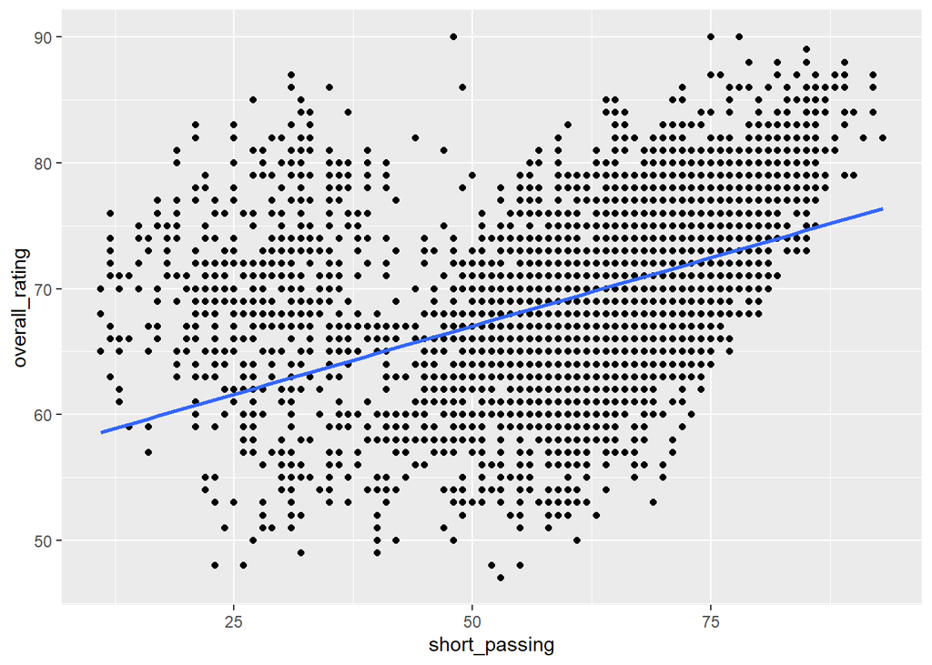

```r
#boxplot(test2016$overall_rating~test2016$short_passing, data=test2016, main="overall_rating vs short_passing", xlab="short_passing", ylab="overall_rating")

ggplot(test2016,aes(y=overall_rating,x=short_passing))+geom_point()+stat_smooth(method="lm",se=FALSE)
```

Let’s try some other significant predictor:

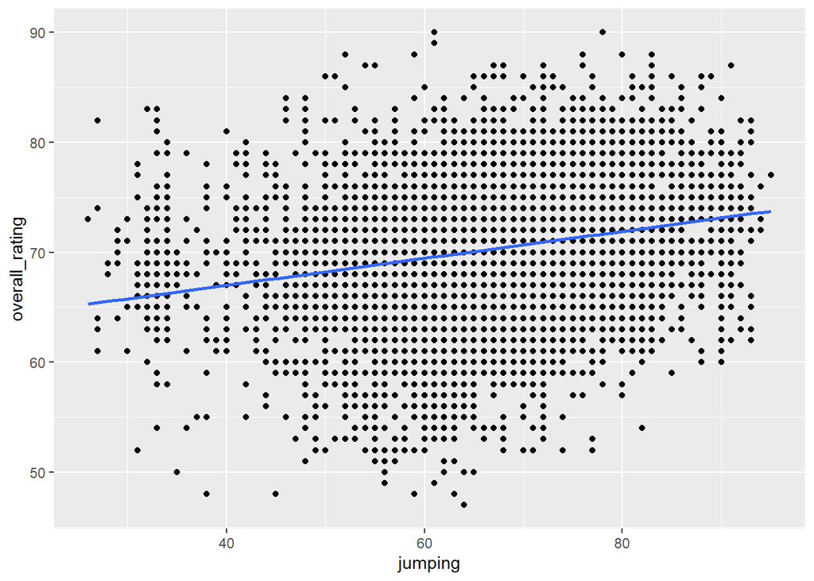

```r
#boxplot(test2016$overall_rating~test2016$jumping, data=test2016, main="overall_rating vs jumping", xlab="jumping", ylab="overall_rating")

ggplot(test2016,aes(y=overall_rating,x=jumping))+geom_point()+stat_smooth(method="lm",se=FALSE)
```

overall_rating vs attacking_work_rate boxplot:

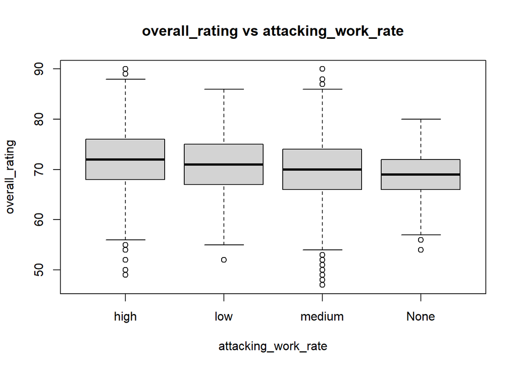

```r
boxplot(test2016$overall_rating~test2016$attacking_work_rate, data=test2016, main="overall_rating vs attacking_work_rate", xlab="attacking_work_rate", ylab="overall_rating")
```

This overall_rating vs attacking_work_rate shows that attacking_work_rate noises are low (within + or - 5). High,low, and medium are good predictors because it covers a wide range. None are insignificant factor as seen in the p-value of summary(fit1).

Now let’s use this fit1 model to predict against **training** dataset test2016:

Predictions:

```r
# testing against the training table test2016:
lm.pred = predict(fit1, data.frame(test2016), interval = "confidence")

# Creating result table
lm.table1 = data.frame(lm.pred)
lm.table1 = cbind(lm.table1, true=test2016[, 8:8])
lm.table1 = cbind(lm.table1, relativeError=(lm.table1$fit-lm.table1$true)/lm.table1$true)
lm.table1 = cbind(lm.table1, percentageError=abs(lm.table1$fit-lm.table1$true)*100/lm.table1$true)
```

Listed random 20 predictions

```r
set.seed(3123)
lm.table1[sample(1:nrow(lm.table1), 20), ]
```

```
##             fit      lwr      upr true relativeError percentageError
## 65367  73.98439 73.77482 74.19396   73  0.0134848319      1.34848319
## 118630 65.48025 65.20204 65.75847   69 -0.0510108450      5.10108450
## 165843 62.14930 61.90195 62.39665   61  0.0188409668      1.88409668
## 31841  65.66133 65.33096 65.99170   62  0.0590537467      5.90537467
## 86757  74.83475 74.63195 75.03756   73  0.0251335969      2.51335969
## 49697  66.50379 66.20242 66.80516   62  0.0726418012      7.26418012
## 95196  76.96988 76.68440 77.25536   77 -0.0003912117      0.03912117
## 9712   63.95795 63.73327 64.18263   66 -0.0309400968      3.09400968
## 22288  76.37617 76.12393 76.62842   79 -0.0332130098      3.32130098
## 101393 68.77557 68.52817 69.02296   67  0.0265010211      2.65010211
## 88752  74.36687 74.02453 74.70921   79 -0.0586471826      5.86471826
## 158630 63.61043 63.02179 64.19908   68 -0.0645524947      6.45524947
## 106477 63.76991 63.48581 64.05402   64 -0.0035950782      0.35950782
## 183645 76.28578 76.05460 76.51695   80 -0.0464277773      4.64277773
## 32615  75.73059 75.38636 76.07483   77 -0.0164858238      1.64858238
## 140327 68.17510 67.94091 68.40928   68  0.0025749485      0.25749485
## 92552  70.29337 70.07911 70.50762   70  0.0041909366      0.41909366
## 36811  74.22156 74.01087 74.43225   74  0.0029939911      0.29939911
## 180909 70.87995 70.63180 71.12811   71 -0.0016908083      0.16908083
## 66336  65.49948 65.21654 65.78242   68 -0.0367723428      3.67723428
```

Average percentage Error

```r
mean(lm.table1$percentageError)
```

```
## [1] 3.088751
```

Above is the prediction table for players in 2016. We can draw some conclusion from this prediction:

The prediction is good to predict the training dataset itself. However, we must test with a test set:

Let’s make another prediction with player stats from 2015 **(test dataset)**

Preparing 2015 data:

```r
# Processing data
test2015 = PlayerTable
test2015$date<- substr(test2015$date, 1, 4) # change year to only "20XX" form
# Selecting only year 2015, because the data is very big
test2015 = test2015[test2015$date == "2015", ]

# Original data was inconsistent. Changing some value in defensive_work_rate for consistency (low, medium, high) not (1,2,3...9)
test2015$defensive_work_rate[test2015$defensive_work_rate == "1" | test2015$defensive_work_rate == "2" | test2015$defensive_work_rate == "3"] <- "low"
test2015$defensive_work_rate[test2015$defensive_work_rate == "4" | test2015$defensive_work_rate == "5" | test2015$defensive_work_rate == "6"] <- "medium"
test2015$defensive_work_rate[test2015$defensive_work_rate == "7" | test2015$defensive_work_rate == "8" | test2015$defensive_work_rate == "9"] <- "high"

# Original data was inconsistent. Changing some value in attacking_work_rate for consistency (low, medium, high) not (1,2,3...9)
test2015$attacking_work_rate[test2015$attacking_work_rate == "1" | test2015$attacking_work_rate == "2" | test2015$attacking_work_rate == "3"] <- "low"
test2015$attacking_work_rate[test2015$attacking_work_rate == "4" | test2015$attacking_work_rate == "5" | test2015$attacking_work_rate == "6"] <- "medium"
test2015$attacking_work_rate[test2015$attacking_work_rate == "7" | test2015$attacking_work_rate == "8" | test2015$attacking_work_rate == "9"] <- "high"

# Change from character to factor
test2015$preferred_foot <- as.factor(test2015$preferred_foot)
test2015$attacking_work_rate <- as.factor(test2015$attacking_work_rate)
test2015$defensive_work_rate <- as.factor(test2015$defensive_work_rate)
```

Predictions:

```r
# using fit1 model to predict on test2015 dataset
lm.pred = predict(fit1, data.frame(test2015), interval = "confidence")

# Creating result table
lm.table2 = data.frame(lm.pred)
lm.table2 = cbind(lm.table2, true=test2015[, 8:8])
lm.table2 = cbind(lm.table2, relativeError=(lm.table2$fit-lm.table2$true)/lm.table2$true)
lm.table2 = cbind(lm.table2, percentageError=abs(lm.table2$fit-lm.table2$true)*100/lm.table2$true)
```

Listed random 20 predictions

```r
set.seed(234)
lm.table2[sample(1:nrow(lm.table2), 20), ]
```

```
##             fit      lwr      upr true relativeError percentageError
## 92980  68.41145 68.12930 68.69359   70 -0.0226936337      2.26936337
## 111414 66.09703 65.72940 66.46466   73 -0.0945611812      9.45611812
## 7803   73.06123 72.88779 73.23466   69  0.0588583731      5.88583731
## 108270 65.23618 64.95819 65.51416   64  0.0193152552      1.93152552
## 25328  64.06763 63.79879 64.33646   64  0.0010566458      0.10566458
## 51978  74.97734 74.70426 75.25042   78 -0.0387520845      3.87520845
## 165728 67.53733 67.28017 67.79449   71 -0.0487699640      4.87699640
## 84139  71.55618 71.16924 71.94313   70  0.0222311822      2.22311822
## 165359 74.25879 74.05585 74.46173   74  0.0034971561      0.34971561
## 112626 80.06108 79.73491 80.38725   80  0.0007635116      0.07635116
## 21729  67.67575 67.43077 67.92073   65  0.0411653685      4.11653685
## 18604  68.08643 67.55853 68.61434   66  0.0316126146      3.16126146
## 31153  69.37086 69.10348 69.63825   56  0.2387654247     23.87654247
## 31178  68.39452 68.12863 68.66042   69 -0.0087750038      0.87750038
## 492    66.15661 65.91401 66.39920   66  0.0023728566      0.23728566
## 167474 62.89946 62.56740 63.23151   60  0.0483243033      4.83243033
## 123860 70.22731 70.01322 70.44140   66  0.0640501277      6.40501277
## 91007  69.34016 69.00135 69.67898   68  0.0197082726      1.97082726
## 49873  75.20560 74.83030 75.58090   75  0.0027413123      0.27413123
## 151249 70.14120 69.87887 70.40354   71 -0.0120957363      1.20957363
```

Average percentage Error

```r
mean(lm.table2$percentageError)
```

```
## [1] 3.274805
```

Above is the prediction table for players in 2015 using fit1 model training with players in 2016. We can draw some conclusion from this prediction:

-> **Conclusion**: Multiple linear regression model fits really well in predicting a numeric overall_rating value of a player based on different numeric and categorial attributes.

**Non-linear regression**

One thing missing from the PlayerTable is the role of the player. A player’s role is important to evaluate a player. An attacking player would have better attacking stats: shooting, dribbling, speed, … A defensive player emphasizes on defensive stats: sliding_tackles, standing_tackles, intercept, aggresion,… A goalkeeper is different than others with their own stats: gk_diving, gk_reflex, … If we can categorize a player into different roles, we can evaluate them better base on the important stats.

In this section, we try to answer this following question: **“How do categorize a player into different roles?”** Since we don’t have roles in any table or any relation table, we need to make one our own by looking up on some official websites (FIFA.com, or Wiki.com site will usually tell you if the player is famous enough). The strategy are as followed:

- Creating new training dataset by adding new column name: role
- Try multiple non-linear regression method
- Predict on a test set. Now since we don’t have an actual test set to compare either, we can again rely on official sites to determine if our prediction is correct or not.
- Or we can use unsupervised prediction, by grouping up close related player, classify base on relationship.
- Figure out a best fitted model. Comments on discovery

Preparing test dataset:

```r
# Processing data
role2016 = PlayerTable
role2016$date<- substr(role2016$date, 1, 4) # change year to only "20XX" form
# Selecting only year 2016, because the data is very big
role2016 = role2016[role2016$date == "2016", ]

# Original data was inconsistent. Changing some value in defensive_work_rate for consistency (low, medium, high) not (1,2,3...9)
role2016$defensive_work_rate[role2016$defensive_work_rate == "1" | role2016$defensive_work_rate == "2" | role2016$defensive_work_rate == "3"] <- "low"
role2016$defensive_work_rate[role2016$defensive_work_rate == "4" | role2016$defensive_work_rate == "5" | role2016$defensive_work_rate == "6"] <- "medium"
role2016$defensive_work_rate[role2016$defensive_work_rate == "7" | role2016$defensive_work_rate == "8" | role2016$defensive_work_rate == "9"] <- "high"

# Original data was inconsistent. Changing some value in attacking_work_rate for consistency (low, medium, high) not (1,2,3...9)
role2016$attacking_work_rate[role2016$attacking_work_rate == "1" | role2016$attacking_work_rate == "2" | role2016$attacking_work_rate == "3"] <- "low"
role2016$attacking_work_rate[role2016$attacking_work_rate == "4" | role2016$attacking_work_rate == "5" | role2016$attacking_work_rate == "6"] <- "medium"
role2016$attacking_work_rate[role2016$attacking_work_rate == "7" | role2016$attacking_work_rate == "8" | role2016$attacking_work_rate == "9"] <- "high"

# Change from character to factor
role2016$preferred_foot <- as.factor(role2016$preferred_foot)
role2016$attacking_work_rate <- as.factor(role2016$attacking_work_rate)
role2016$defensive_work_rate <- as.factor(role2016$defensive_work_rate)

# Adding role column, give random value
set.seed(2313)
roles <- c("Attacker", "Defender", "Goalkeeper")
role2016$role <- sample(roles, size = nrow(role2016), replace = TRUE)

# Manually selecting some players and give them the correct role:
  # Goalkeepers
p1 = role2016[role2016$player_api_id == 182917, ]
p1["role"] <- "Goalkeeper"
p2 = role2016[role2016$player_api_id == 30717, ]
p2["role"] <- "Goalkeeper"
p3 = role2016[role2016$player_api_id == 27299, ]
p3["role"] <- "Goalkeeper"
p4 = role2016[role2016$player_api_id == 30859, ]
p4["role"] <- "Goalkeeper"
p5 = role2016[role2016$player_api_id == 51949, ]
p5["role"] <- "Goalkeeper"

 # Attackers
p6 = role2016[role2016$player_api_id == 169200, ]
p6["role"] <- "Attacker"
p7 = role2016[role2016$player_api_id == 23354, ]
p7["role"] <- "Attacker"
p8 = role2016[role2016$player_api_id == 286119, ]
p8["role"] <- "Attacker"
p9 = role2016[role2016$player_api_id == 30822, ]
p9["role"] <- "Attacker"
p10 = role2016[role2016$player_api_id == 30853, ]
p10["role"] <- "Attacker"


  # Defenders
p11 = role2016[role2016$player_api_id == 30865, ]
p11["role"] <- "Defender"
p12 = role2016[role2016$player_api_id == 150739, ]
p12["role"] <- "Defender"
p13 = role2016[role2016$player_api_id == 30962, ]
p13["role"] <- "Defender"
p14 = role2016[role2016$player_api_id == 186137, ]
p14["role"] <- "Defender"
p15 = role2016[role2016$player_api_id == 56678, ]
p15["role"] <- "Defender"

  # Add some more because of singularity
p16 = role2016[role2016$player_api_id == 184554, ]
p16["role"] <- "Goalkeeper"
p17 = role2016[role2016$player_api_id == 42422, ]
p17["role"] <- "Goalkeeper"
p18 = role2016[role2016$player_api_id == 26295, ]
p18["role"] <- "Goalkeeper"
p19 = role2016[role2016$player_api_id == 177126, ]
p19["role"] <- "Goalkeeper"
p20 = role2016[role2016$player_api_id == 40604, ]
p20["role"] <- "Goalkeeper"

p21 = role2016[role2016$player_api_id == 363333, ]
p21["role"] <- "Attacker"
p22 = role2016[role2016$player_api_id == 150565, ]
p22["role"] <- "Attacker"
p23 = role2016[role2016$player_api_id == 194165, ]
p23["role"] <- "Attacker"
p24 = role2016[role2016$player_api_id == 184536, ]
p24["role"] <- "Attacker"
p25 = role2016[role2016$player_api_id == 107417, ]
p25["role"] <- "Attacker"

p26 = role2016[role2016$player_api_id == 474589, ]
p26["role"] <- "Defender"
p27 = role2016[role2016$player_api_id == 282674, ]
p27["role"] <- "Defender"
p28 = role2016[role2016$player_api_id == 37762, ]
p28["role"] <- "Defender"
p29 = role2016[role2016$player_api_id == 56678, ]
p29["role"] <- "Defender"
p30 = role2016[role2016$player_api_id == 574200, ]
p30["role"] <- "Defender"

# Creating test set:
newrole2016 = rbind(p1, p2, p3, p4, p5, p6, p7, p8, p9, p10, p11, p12, p13, p14, p15,
                    p16, p17, p18, p19, p20, p21, p22, p23, p24, p25, p26, p27, p28, p29, p30)
# Change from character to factor
newrole2016$role <- as.factor(newrole2016$role)
```

Let’s plot some graph:

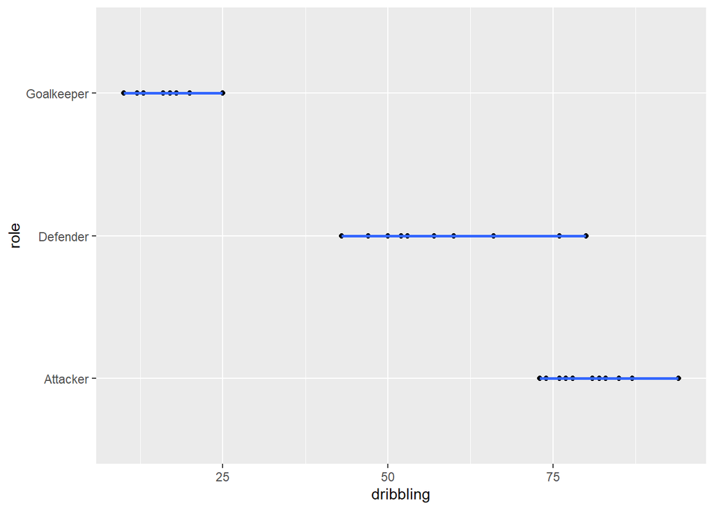

```r
ggplot(newrole2016,aes(y=role,x=dribbling))+geom_point()+geom_smooth(method="glm")
```

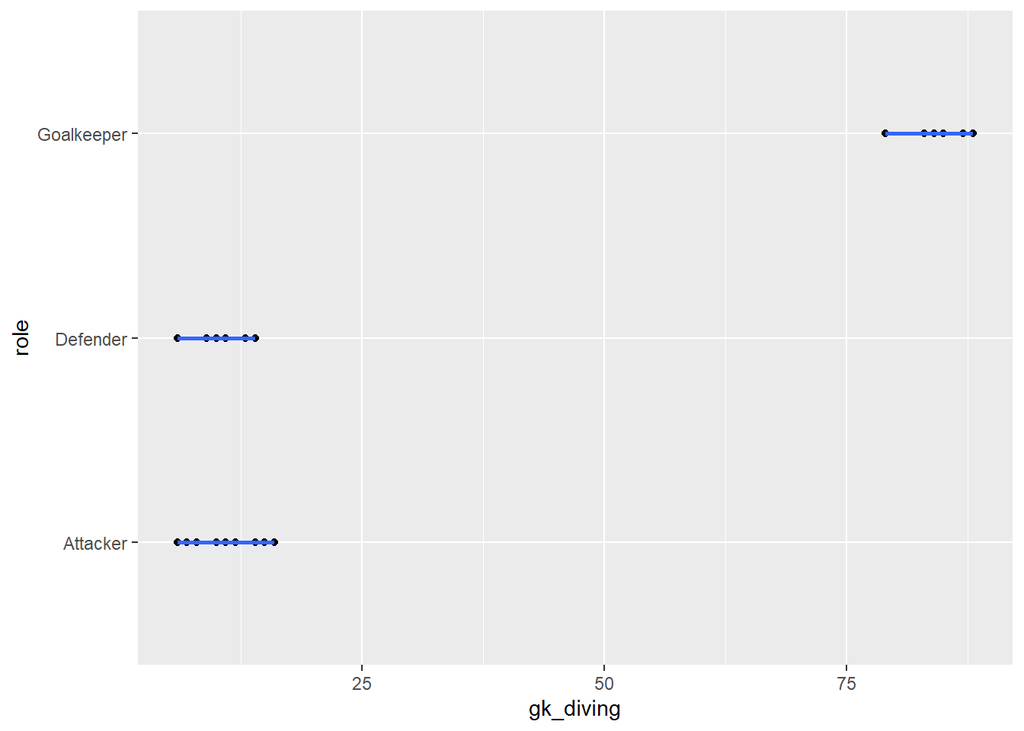

```r
ggplot(newrole2016,aes(y=role,x=gk_diving))+geom_point()+geom_smooth(method="glm")
```

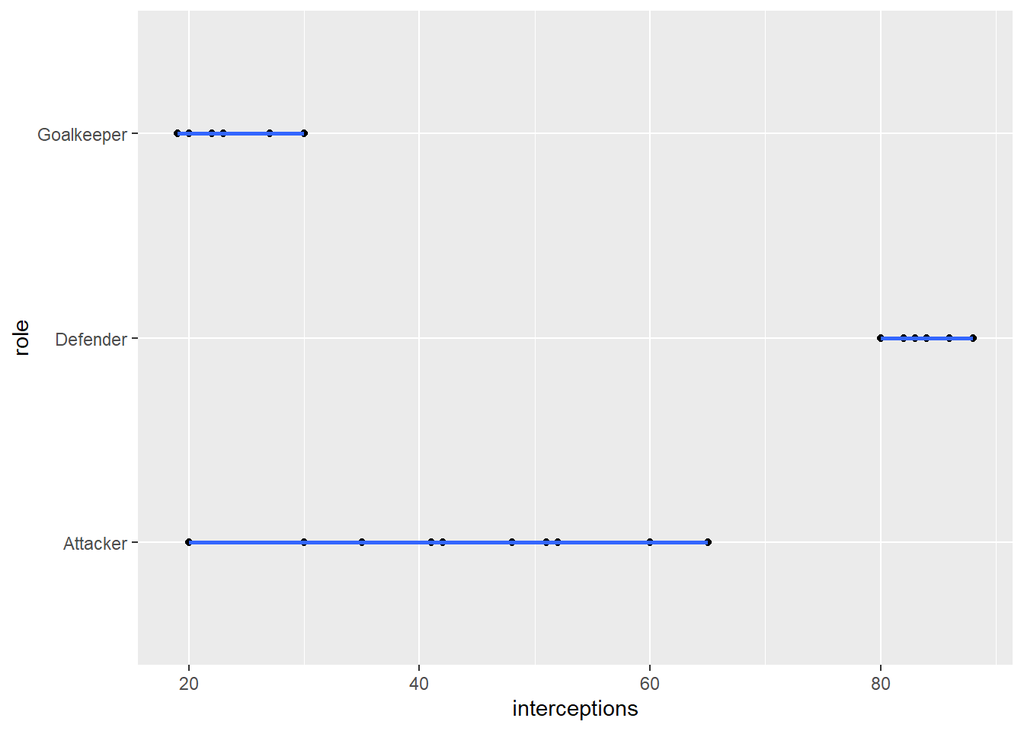

```r
ggplot(newrole2016,aes(y=role,x=interceptions))+geom_point()+geom_smooth(method="glm")
```

We can draw some conclusion from the given graph on limited train set:

- Dribbling has strong relation ship with attackers, medium with defender and little effect on goalkeeper
- Interception has strong relation ship with defenders, low with attacker and little effect on goalkeeper
- gk_diving has strong relation ship with goalkeeper, little effect on attacker and defender
- -> This is in fact true due to common sense.

Let’s train on this new train set using **logistic regression**:

```r
# glm
fit2 = glm(newrole2016$role~., data=newrole2016[ , -which(names(newrole2016) %in% c("player_api_id","player_fifa_api_id", "player_name", "birthday", "date", "overall_rating", "potential"))], family="binomial")
summary(fit2)
```

```
##
## Call:
## glm(formula = newrole2016$role ~ ., family = "binomial", data = newrole2016[,
##     -which(names(newrole2016) %in% c("player_api_id", "player_fifa_api_id",
##         "player_name", "birthday", "date", "overall_rating",
##         "potential"))])
##
## Deviance Residuals:
##        Min          1Q      Median          3Q         Max
## -3.592e-06  -2.381e-06   2.042e-06   2.409e-06   3.344e-06
##
## Coefficients:
##                             Estimate Std. Error z value Pr(>|z|)
## (Intercept)               -5.291e+02  3.552e+07       0        1
## height                     1.515e+00  1.285e+05       0        1
## weight                     5.371e-01  5.886e+04       0        1
## preferred_footright       -1.526e+01  1.201e+06       0        1
## attacking_work_ratelow    -1.664e+01  2.470e+06       0        1
## attacking_work_ratemedium -1.727e+00  1.753e+06       0        1
## defensive_work_ratelow    -1.986e+01  1.977e+06       0        1
## defensive_work_ratemedium -1.926e+01  1.924e+06       0        1
## crossing                   9.267e-01  7.467e+04       0        1
## finishing                 -8.183e-01  7.152e+04       0        1
## heading_accuracy           8.505e-01  8.479e+04       0        1
## short_passing             -1.209e+00  1.261e+05       0        1
## volleys                   -9.926e-02  2.838e+04       0        1
## dribbling                 -6.849e-01  1.079e+05       0        1
## curve                      5.234e-01  8.391e+04       0        1
## free_kick_accuracy        -8.180e-01  1.127e+05       0        1
## long_passing               1.321e+00  1.122e+05       0        1
## ball_control               4.976e-01  1.008e+05       0        1
## acceleration              -5.071e-01  7.395e+04       0        1
## sprint_speed               8.993e-01  8.126e+04       0        1
## agility                    5.360e-01  5.743e+04       0        1
## reactions                  8.214e-02  4.050e+04       0        1
## balance                    8.314e-01  7.142e+04       0        1
## shot_power                -7.594e-01  5.547e+04       0        1
## jumping                    1.053e+00  5.277e+04       0        1
## stamina                   -2.700e-01  5.265e+04       0        1
## strength                   1.381e-01  6.040e+04       0        1
## long_shots                 9.955e-01  1.378e+05       0        1
## aggression                -6.167e-02  4.377e+04       0        1
## interceptions             -4.286e-01  5.125e+04       0        1
## positioning                2.381e-02  5.971e+04       0        1
## vision                    -1.554e-01  4.146e+04       0        1
## penalties                 -5.940e-01  5.818e+04       0        1
## marking                    9.262e-02  8.587e+04       0        1
## standing_tackle            1.752e+00  1.181e+05       0        1
## sliding_tackle            -1.527e+00  6.217e+04       0        1
## gk_diving                  1.287e+00  1.438e+05       0        1
## gk_handling               -1.860e-01  1.583e+05       0        1
## gk_kicking                -1.470e-01  7.080e+04       0        1
## gk_positioning             9.417e-03  1.195e+05       0        1
## gk_reflexes               -4.414e-01  1.809e+05       0        1
##
## (Dispersion parameter for binomial family taken to be 1)
##
##     Null deviance: 1.0364e+02  on 74  degrees of freedom
## Residual deviance: 4.3892e-10  on 34  degrees of freedom
## AIC: 82
##
## Number of Fisher Scoring iterations: 25
```

—————–## UPDATE ## ——————-

Comments on the general multiple logistic model:

- The deviance residuals value is good. Similar (1Q, 3Q), (min, max). Median is close to 0
- However, the z value and Pr(<|z|) (or p-value) are 0 and 1 respectively, showing that none of our data is significant
- **The data is not big enough with variety. When testing with lda model, we get a similar result with a warning: Error in lda.default(x, grouping, …) : variable 6 appears to be constant within groups. So we can see that a model that try to draw a line/non-linear line to fit a low amount of data will not work well**
- -> This is a big limited of logistic model if we are operating on limited **and not enough variety** known training set. Despite the graph showing good relationship on some factors, we will not be using this model further on.
- **In the next section, we switch to Naive Bayes. The reason is Naive Bayes work with probability, it is not trying to fit lines. So let’s hope this works out.**

———————###————————-

Let’s train on this new train set using **Naive Bayes** probability method:

Let’s first plot some graph. We will not be using pairs(data[,]) because there are so many predictors. We will focus on some relationship that makes sense, then later test with model:

Checking plot: role-goalkeeper vs gk_diving+gk_handling+gk_kicking+gk_positioning+gk_reflexes:

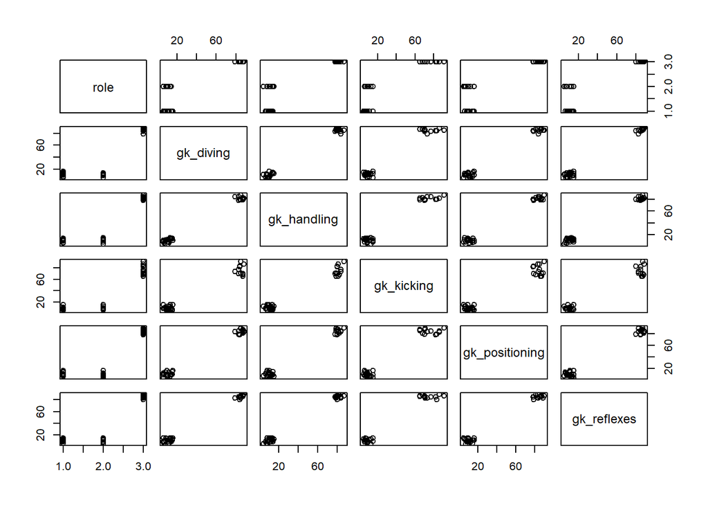

```r
pairs(~role+gk_diving+gk_handling+gk_kicking+gk_positioning+gk_reflexes, data=newrole2016)
```

Checking plot: role-attacker vs attacking_work_rate +sprint_speed+volleys+dribbling+shot_power:

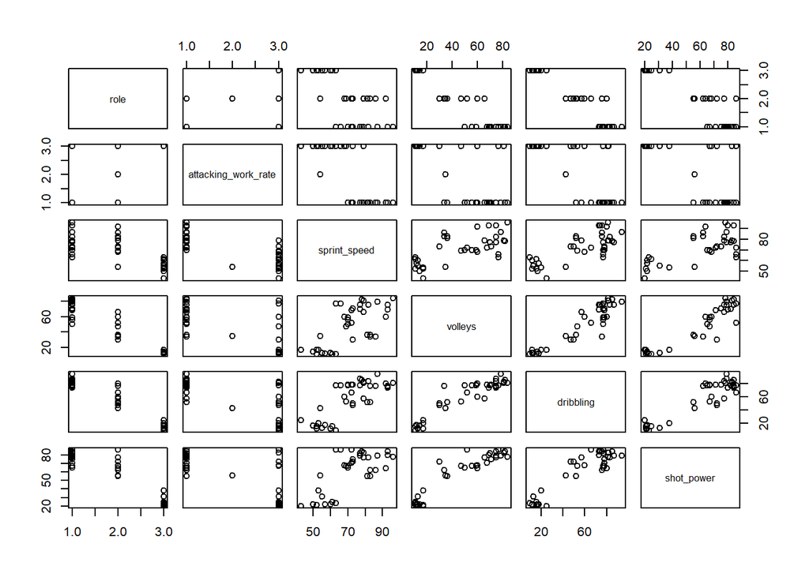

```r
pairs(~role+attacking_work_rate +sprint_speed+volleys+dribbling+shot_power, data=newrole2016)
```

Checking plot: role-defender vs defensive_work_rate+ aggression+ standing_tackle+ sliding_tackle+ interceptions:

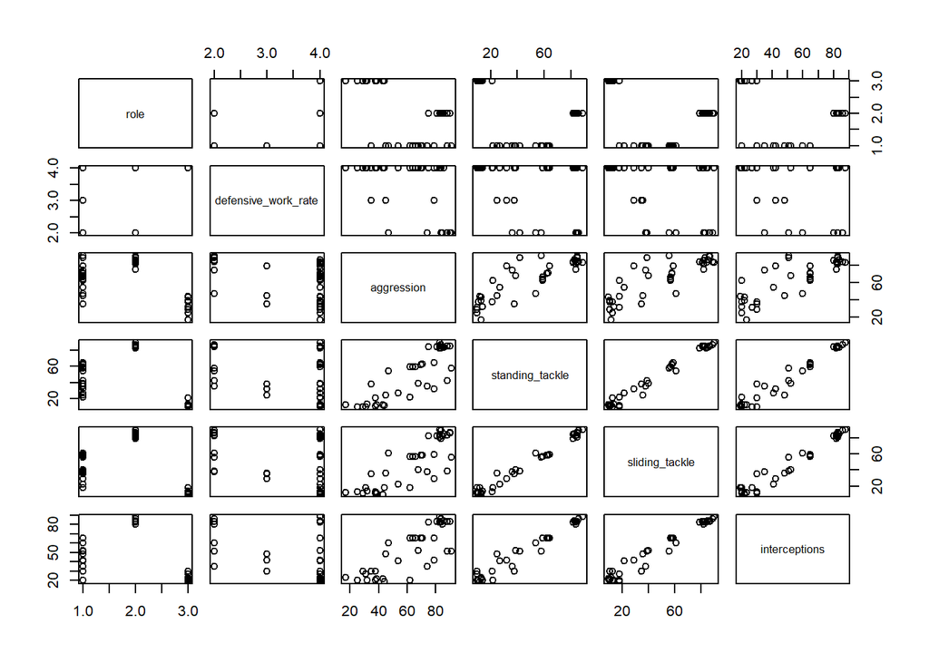

```r
pairs(~role+defensive_work_rate +aggression+standing_tackle+sliding_tackle+interceptions, data=newrole2016)
```

The main idea of these plots are to check the relationship with three roles attacker, defender and goalkeeper. If we just look at the first row of the plots, they are relationship between role and other factors. Drawing conclusion from these rows, as expected:

- The more gk_diving+gk_handling+gk_kicking+gk_positioning+gk_reflexes, the better chance this is a goalkeeper, very low chance of being a defender or attacker
- The more attacking_work_rate +sprint_speed+volleys+dribbling+shot_power, the better chance this player is an attacker, low chance of being a goalkeeper. However, shot_power and sprint_speed still somewhat affect the probability of being a defender.
- The more defensive_work_rate+ aggression+ standing_tackle+ sliding_tackle+ interceptions, the better chance this is a defender, low chance of being a goalkeeper. However, aggression still somewhat contributes to a defender’s probability

Let’s figure them out by using Naive Bayes probability model:

Fit Naive Bayes model:

```r
#
fit3 <- naive_bayes(newrole2016$role~., data=newrole2016[ , -which(names(newrole2016) %in% c("player_api_id","player_fifa_api_id", "player_name", "birthday", "date", "overall_rating", "potential"))])
print(fit3[8])
```

```
## $call
## naive_bayes.formula(formula = newrole2016$role ~ ., data = newrole2016[,
##     -which(names(newrole2016) %in% c("player_api_id", "player_fifa_api_id",
##         "player_name", "birthday", "date", "overall_rating",
##         "potential"))])
```

```r
print(fit3[5])
```

```
## $prior
##
##   Attacker   Defender Goalkeeper
##  0.4666667  0.2533333  0.2800000
```

```r
print(fit3[4])
```

```
## $tables
##
## ---------------------------------------------------------------------------------
##  ::: height (Gaussian)
## ---------------------------------------------------------------------------------
##
## height   Attacker   Defender Goalkeeper
##   mean 182.952571 184.216842 190.862857
##   sd     5.560963   5.765323   3.140339
##
## ---------------------------------------------------------------------------------
##  ::: weight (Gaussian)
## ---------------------------------------------------------------------------------
##
## weight   Attacker   Defender Goalkeeper
##   mean 164.857143 168.000000 190.190476
##   sd    10.541634  11.215069   9.516402
##
## ---------------------------------------------------------------------------------
##  ::: preferred_foot (Bernoulli)
## ---------------------------------------------------------------------------------
##
## preferred_foot  Attacker  Defender Goalkeeper
##          left  0.0000000 0.1052632  0.1904762
##          right 1.0000000 0.8947368  0.8095238
##
## ---------------------------------------------------------------------------------
##  ::: attacking_work_rate (Categorical)
## ---------------------------------------------------------------------------------
##
## attacking_work_rate   Attacker   Defender Goalkeeper
##              high   0.74285714 0.52631579 0.00000000
##              low    0.00000000 0.05263158 0.00000000
##              medium 0.25714286 0.42105263 1.00000000
##              None   0.00000000 0.00000000 0.00000000
##
## ---------------------------------------------------------------------------------
##  ::: defensive_work_rate (Categorical)
## ---------------------------------------------------------------------------------
##
```

[output cut: 256 more lines]

```
## ---------------------------------------------------------------------------------
##
## gk_positioning  Attacker  Defender Goalkeeper
##           mean 11.000000  9.631579  83.904762
##           sd    3.360672  3.336840   4.241518
##
## ---------------------------------------------------------------------------------
##  ::: gk_reflexes (Gaussian)
## ---------------------------------------------------------------------------------
##
## gk_reflexes  Attacker  Defender Goalkeeper
##        mean 10.600000 11.263158  85.523810
##        sd    2.557572  3.429320   2.600366
##
## ---------------------------------------------------------------------------------
```

Interpreting the Naive Bayes model result:

- Looking at priority table, there are 46.66% attacker, 25.33% defender and 28% goalkeeper. This information is not major, but true to the common knowledge. Now let’s take a look at the table:
- If we look at categorical predictor:
  - preferred_foot: some of the left-foot player are goalkeeper or defender, most of them are right footed and evenly distributed. We have strange probability here because of limited train data
  - attacking/defending_work_rate: We have the same strange probability. However, notice that most attacking_work_rate high has good chance of being an attacker. Same applies to defender
- If we look at numeric predictor, besides height and weight, the value are in range 0-100:
  - Goalkeeper usually has better height and weight than regular player. Height is important to a goalkeeper, that’s a fact
  - There is a good chance a player is a goalkeeper if they have these high stats(>= 75): reactions, strength, jumping, gk_diving, gk_handling, gk_kicking, gk_positionning, gk_reflexes.
  - There is a good chance a player is an attacker if they have these high stats(>= 75): finishing, dribbling, ball_control, acceleration, sprint_speed, agility, reactions, shot_power, stamina, positioning, vision.
  - There is a good chance a player is a defender if they have these high stats(>= 75): heading_accuracy, sprint_speed, reactions, jumping, stamina, strength, aggression, interceptions, marking, standing_tackle, sliding_tackle.
  - There is one predictor: reactions that show up in all three roles, we can conclude that either everyone has high reactions skill or the data does not have enough variety.
  - -> The predictors give good chance of predicting a correct role. We can use this model for prediction some test data.

Predictions:

```r
# newrole2016 is new training set, we can use test2015 as test set
naives_bayes.pred = predict(fit3, test2015, type = 'prob')
```

Since we don’t have a test result to compare with, we will attach the prediction table to the original data set and make observations:

Making table result

```r
# Adding Naive Bayes prediction to test2015 test set
resultNB = test2015
resultNB = cbind(resultNB, data.frame(naives_bayes.pred))
# -> resultNB will hold all the role predictions for test2015 test-set
```

Select 5 known player as predictors:

```r
nb1 = resultNB[resultNB$player_api_id == 30893, ]
nb2 = resultNB[resultNB$player_api_id == 30981, ]
nb3 = resultNB[resultNB$player_api_id == 30717, ]
nb4 = resultNB[resultNB$player_api_id == 248453, ]
nb5 = resultNB[resultNB$player_api_id == 39027, ]

resultNB5 = rbind(nb1, nb2, nb3, nb4, nb5)
print(resultNB5)
```

```
##        player_api_id player_fifa_api_id       player_name            birthday
## 98150          30893              20801 Cristiano Ronaldo 1985-02-05 00:00:00
## 98157          30893              20801 Cristiano Ronaldo 1985-02-05 00:00:00
## 98158          30893              20801 Cristiano Ronaldo 1985-02-05 00:00:00
## 98160          30893              20801 Cristiano Ronaldo 1985-02-05 00:00:00
## 98162          30893              20801 Cristiano Ronaldo 1985-02-05 00:00:00
## 99708          30981             158023      Lionel Messi 1987-06-24 00:00:00
## 99711          30981             158023      Lionel Messi 1987-06-24 00:00:00
## 99713          30981             158023      Lionel Messi 1987-06-24 00:00:00
## 99717          30981             158023      Lionel Messi 1987-06-24 00:00:00
## 99721          30981             158023      Lionel Messi 1987-06-24 00:00:00
## 99722          30981             158023      Lionel Messi 1987-06-24 00:00:00
## 99725          30981             158023      Lionel Messi 1987-06-24 00:00:00
## 96315          30717               1179  Gianluigi Buffon 1978-01-28 00:00:00
## 96322          30717               1179  Gianluigi Buffon 1978-01-28 00:00:00
```

[output cut: 219 more lines]

Above is the prediction table for players in 2015 using fit3 Naive_Bayes model training with some players in 2016. Because of the limited test set, we can draw some conclusion based on observations: (Note*: There are some multiple data per person, this came from different period of the year):

- Cristiano Ronaldo, Messi and Paul Pogba is classified as attacking role, which is true. They have good attacking stats (shooting ,passing, speed, …)
- Vincent Kompany is classified as a defender, which is true. He has good defensive stats (tackling, defende_working_rate, strength, jump, ..)
- Gianluigi Buffon is a goalkeeper, which is true. He has all high goalkeeping stats (gl_xxx, …)

## Exploring Decision tree

**Question** Another technique in classification using in R is tree. We’d like to answer a type of question to utilize tree. Given the data above, and some analysis in the non-linear section. Let’s answer this question: **How can you tell if a player is an attacking player or not?**. The strategy is to build a **decision tree**

Preparing testset and trainset

```r
## TRAIN
dt2015 = test2015

dt2015$attacking_work_rate[dt2015$attacking_work_rate == "low" | dt2015$attacking_work_rate == "medium" | dt2015$attacking_work_rate == "None"] <- "low"
dt2015$defensive_work_rate[dt2015$defensive_work_rate == "low" | dt2015$defensive_work_rate == "medium" | dt2015$defensive_work_rate == "0"] <- "low"

#choosing meaningful training data: dt2015
dt2015 <- select(dt2015, height, weight, overall_rating, preferred_foot, attacking_work_rate, crossing, finishing, heading_accuracy, short_passing, volleys, dribbling, curve, free_kick_accuracy, long_passing, ball_control, acceleration, sprint_speed, agility, reactions, balance, shot_power, jumping, stamina, strength, long_shots, aggression, interceptions, positioning, vision, penalties, marking, standing_tackle, sliding_tackle, gk_diving, gk_handling, gk_kicking, gk_positioning, gk_reflexes)


## TEST
dt2016 = test2016

dt2016$attacking_work_rate[dt2016$attacking_work_rate == "low" | dt2016$attacking_work_rate == "medium" | dt2016$attacking_work_rate == "None"] <- "low"
dt2016$defensive_work_rate[dt2016$defensive_work_rate == "low" | dt2016$defensive_work_rate == "medium" | dt2016$defensive_work_rate == "0"] <- "low"

#choosing meaningful test data: dt2016
dt2016 <- select(dt2016, height, weight, overall_rating, preferred_foot, attacking_work_rate, crossing, finishing, heading_accuracy, short_passing, volleys, dribbling, curve, free_kick_accuracy, long_passing, ball_control, acceleration, sprint_speed, agility, reactions, balance, shot_power, jumping, stamina, strength, long_shots, aggression, interceptions, positioning, vision, penalties, marking, standing_tackle, sliding_tackle, gk_diving, gk_handling, gk_kicking, gk_positioning, gk_reflexes)
```

Build tree

```r
tree <- rpart(attacking_work_rate~., data = dt2015)
```

Predictions

```r
# predict against test set dt2016
tree.attacking_work_rate.pred <- predict(tree, dt2016, type='class')
```

Evaluating the model

```r
confusionMatrix(tree.attacking_work_rate.pred, dt2016$attacking_work_rate)
```

```
## Confusion Matrix and Statistics
##
##           Reference
## Prediction high  low medium None
##     high   1590  861      0    0
##     low    2866 8767      0    0
##     medium    0    0      0    0
##     None      0    0      0    0
##
## Overall Statistics
##
##                Accuracy : 0.7354
##                  95% CI : (0.728, 0.7426)
##     No Information Rate : 0.6836
##     P-Value [Acc > NIR] : < 2.2e-16
##
##                   Kappa : 0.3042
##
##  Mcnemar's Test P-Value : NA
##
## Statistics by Class:
##
##                      Class: high Class: low Class: medium Class: None
## Sensitivity               0.3568     0.9106            NA          NA
## Specificity               0.9106     0.3568             1           1
## Pos Pred Value            0.6487     0.7536            NA          NA
## Neg Pred Value            0.7536     0.6487            NA          NA
## Prevalence                0.3164     0.6836             0           0
## Detection Rate            0.1129     0.6225             0           0
## Detection Prevalence      0.1740     0.8260             0           0
## Balanced Accuracy         0.6337     0.6337            NA          NA
```

Some comments on the confusion matrix:

- The accuracy is 0.7354 or 73.54%, this is only a decent model.
- Looking at precition and reference table:
  - There are 1590 correct prediction on attacking player and 8767 prediction on this is not an attacking player. There were 861 prediction on attacking player (false-negative), but in fact this is not an attacking player, so low false-negative. There were 2866 prediction on not an attacking player (false-positive), but in fact this is an attacking player, so low false-positive. The false-negative value is low so this prediction is not the worst case scenario
- P-Value [Acc > NIR] : < 2.2e-16 so we can say the predictors are statistically significant

Visualization example:

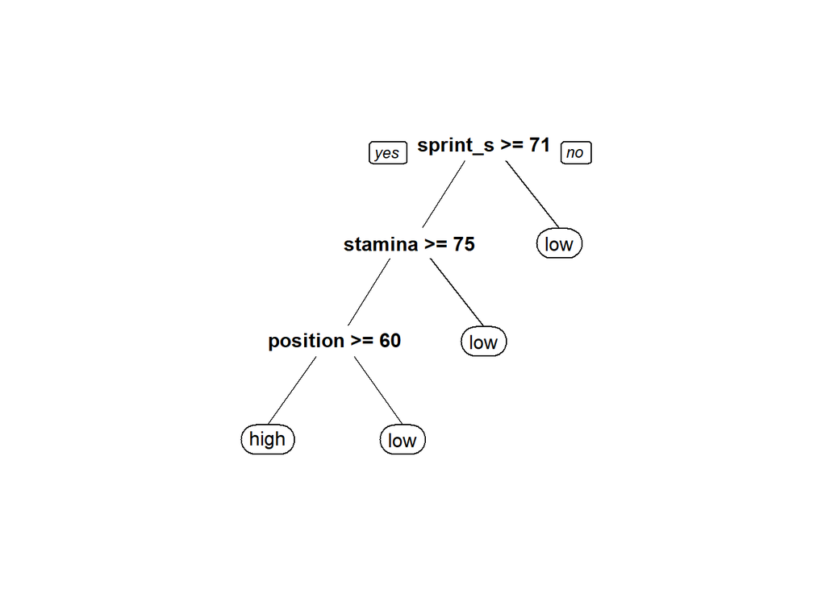

```r
prp(tree)
```

**Multiple logistic model**

Let’s give logistic model a redemption arc on predicting binary value (only 2-classification) and see if it performs better than decision tree.

Quick test on statistically significant:

```r
# glm
fit4 = glm(dt2015$attacking_work_rate~., data=dt2015, family="binomial")
summary(fit4)
```

```
##
## Call:
## glm(formula = dt2015$attacking_work_rate ~ ., family = "binomial",
##     data = dt2015)
##
## Deviance Residuals:
##     Min       1Q   Median       3Q      Max
## -3.1529  -0.8396   0.3686   0.7936   1.9685
##
## Coefficients:
##                       Estimate Std. Error z value Pr(>|z|)
## (Intercept)          4.539e+00  9.318e-01   4.871 1.11e-06 ***
## height               2.312e-02  4.821e-03   4.796 1.62e-06 ***
## weight               1.643e-03  1.743e-03   0.943 0.345926
## overall_rating       1.939e-02  5.993e-03   3.235 0.001215 **
## preferred_footright  5.594e-03  3.404e-02   0.164 0.869441
## crossing            -1.939e-02  2.007e-03  -9.659  < 2e-16 ***
## finishing           -1.517e-02  2.330e-03  -6.512 7.43e-11 ***
## heading_accuracy    -5.334e-03  1.957e-03  -2.726 0.006409 **
## short_passing        2.327e-02  4.139e-03   5.623 1.88e-08 ***
## volleys              6.747e-03  1.961e-03   3.440 0.000582 ***
## dribbling           -1.712e-02  3.674e-03  -4.660 3.17e-06 ***
## curve               -8.907e-03  1.918e-03  -4.644 3.42e-06 ***
## free_kick_accuracy  -3.458e-05  1.653e-03  -0.021 0.983316
## long_passing         1.608e-02  2.701e-03   5.953 2.63e-09 ***
## ball_control         8.624e-03  4.903e-03   1.759 0.078615 .
## acceleration        -2.079e-02  3.766e-03  -5.521 3.36e-08 ***
## sprint_speed        -3.187e-02  3.417e-03  -9.326  < 2e-16 ***
## agility             -4.318e-03  2.730e-03  -1.582 0.113673
## reactions            3.555e-03  3.268e-03   1.088 0.276581
## balance              7.585e-03  2.608e-03   2.908 0.003633 **
## shot_power          -1.579e-03  2.491e-03  -0.634 0.526210
## jumping              6.052e-03  1.587e-03   3.813 0.000137 ***
## stamina             -4.396e-02  1.992e-03 -22.061  < 2e-16 ***
## strength            -1.825e-03  2.213e-03  -0.825 0.409651
## long_shots           2.175e-03  2.398e-03   0.907 0.364343
## aggression          -8.797e-03  1.508e-03  -5.834 5.40e-09 ***
## interceptions        1.174e-03  2.065e-03   0.568 0.569705
## positioning         -4.153e-02  2.443e-03 -17.005  < 2e-16 ***
## vision               3.876e-03  2.469e-03   1.570 0.116422
## penalties            2.689e-03  1.891e-03   1.422 0.154945
## marking             -6.899e-03  2.638e-03  -2.615 0.008914 **
## standing_tackle      6.279e-03  3.102e-03   2.024 0.042938 *
## sliding_tackle      -7.817e-03  2.942e-03  -2.657 0.007884 **
## gk_diving            1.144e-02  4.462e-03   2.565 0.010324 *
## gk_handling         -2.703e-03  4.481e-03  -0.603 0.546333
## gk_kicking           1.937e-02  4.465e-03   4.338 1.44e-05 ***
## gk_positioning      -7.210e-03  4.459e-03  -1.617 0.105891
## gk_reflexes          4.808e-03  4.481e-03   1.073 0.283314
## ---
## Signif. codes:  0 '***' 0.001 '**' 0.01 '*' 0.05 '.' 0.1 ' ' 1
##
## (Dispersion parameter for binomial family taken to be 1)
##
##     Null deviance: 38151  on 31778  degrees of freedom
## Residual deviance: 29417  on 31741  degrees of freedom
## AIC: 29493
##
## Number of Fisher Scoring iterations: 8
```

Comments on finding:

- P-value and z value are distinct now given a good amount of data
- Residual value are good (3Q, 1Q close, max, min close, mean low, close to 0)
- All other factor excepts are statistically important: -weight- preferred_foot- free_kick_accuracy- agility-reactions- strength-long_shots- interceptions- vision- penalties-shot_power- ball_control- gk_handling- gk_positioning- gk_reflexes. We remove the non significant from the equation
- Surprisingly, gk_kicking has p-value = 1.44e-05 is considered significant for an attacking player Now that’s everything is statistically significant, let’s make prediction:

Model:

```r
# glm
fit4 = glm(dt2015$attacking_work_rate~.-weight-preferred_foot-free_kick_accuracy-agility-reactions-strength-long_shots-interceptions-vision-penalties-shot_power-ball_control-gk_handling-gk_positioning-gk_reflexes, data=dt2015, family="binomial")
summary(fit4)
```

```
##
## Call:
## glm(formula = dt2015$attacking_work_rate ~ . - weight - preferred_foot -
##     free_kick_accuracy - agility - reactions - strength - long_shots -
##     interceptions - vision - penalties - shot_power - ball_control -
##     gk_handling - gk_positioning - gk_reflexes, family = "binomial",
##     data = dt2015)
##
## Deviance Residuals:
##     Min       1Q   Median       3Q      Max
## -3.1939  -0.8414   0.3693   0.7954   2.0060
##
## Coefficients:
##                   Estimate Std. Error z value Pr(>|z|)
## (Intercept)       4.508544   0.910824   4.950 7.42e-07 ***
## height            0.024244   0.004452   5.446 5.15e-08 ***
## overall_rating    0.026603   0.004649   5.722 1.05e-08 ***
## crossing         -0.019614   0.001971  -9.950  < 2e-16 ***
## finishing        -0.013916   0.002152  -6.466 1.01e-10 ***
## heading_accuracy -0.005528   0.001905  -2.902 0.003704 **
## short_passing     0.026899   0.003870   6.950 3.66e-12 ***
## volleys           0.007729   0.001863   4.147 3.36e-05 ***
## dribbling        -0.014520   0.003127  -4.644 3.42e-06 ***
## curve            -0.007929   0.001710  -4.637 3.54e-06 ***
## long_passing      0.017454   0.002541   6.868 6.49e-12 ***
## acceleration     -0.022649   0.003629  -6.241 4.34e-10 ***
## sprint_speed     -0.033627   0.003347 -10.047  < 2e-16 ***
## balance           0.007051   0.002486   2.837 0.004561 **
## jumping           0.005435   0.001550   3.507 0.000454 ***
## stamina          -0.043885   0.001939 -22.637  < 2e-16 ***
## aggression       -0.008781   0.001422  -6.174 6.65e-10 ***
## positioning      -0.039854   0.002352 -16.947  < 2e-16 ***
## marking          -0.007162   0.002571  -2.786 0.005339 **
## standing_tackle   0.007126   0.002983   2.389 0.016891 *
## sliding_tackle   -0.007871   0.002921  -2.695 0.007041 **
## gk_diving         0.010076   0.004334   2.325 0.020075 *
## gk_kicking        0.018515   0.004341   4.265 2.00e-05 ***
## ---
## Signif. codes:  0 '***' 0.001 '**' 0.01 '*' 0.05 '.' 0.1 ' ' 1
##
## (Dispersion parameter for binomial family taken to be 1)
##
##     Null deviance: 38151  on 31778  degrees of freedom
## Residual deviance: 29434  on 31756  degrees of freedom
## AIC: 29480
##
## Number of Fisher Scoring iterations: 7
```

Predictions:

```r
glm.prob = predict(fit4, dt2016, type = "response")
glm.pred = rep(0, length(glm.prob))
glm.pred[glm.prob < 0.5] <- 1
glm.pred[glm.prob >= 0.5] <- 0
glm.true = rep(0, length(glm.prob))
glm.true[dt2016$attacking_work_rate == "high"] <- 1
glm.true[dt2016$attacking_work_rate == "low"] <- 0

# Confusion matrix
table(glm.pred, glm.true)
```

```
##         glm.true
## glm.pred    0    1
##        0 8693 2449
##        1  935 2007
```

```r
# Accuracy
mean(glm.pred == glm.true)
```

```
## [1] 0.7597274
```

Some comments on the result of multiple logistic regression:

-> **conclusion**: What can we tell from choosing a binary classification methods:

- Decision tree gave decent visualization, data formation (you need to make a tree, so you’ll be able to tell the factors contributing), but give less accuracy
- Multiple logistic regression performs well under a full (good variety) dataset, identifies correct statistical significant predictors, gives better results than decision tree
- -> If we’d choose a model for a binary classification, a logistic regression method is simple yet effective, will be a better choice.

—————–## UPDATE ## ——————-  
## Generalization ##

We continue to apply our model on earlier years. We choose year 2012 and 2013 because they are the last entry that gives consistency in the table. On earlier year, there are some inconsistency in the data. There is this error: **Error in model.frame.default(Terms, newdata, na.action = na.action, xlev = object$xlevels) :** **factor attacking_work_rate has new levels le, norm, stoc, y** The attacking_work_rate has alwasy been high, medium, low. However, we are unable to explain these value: le, norm, stoc, y because there are no description in the offical site Kaggle. Since it is hard to inpterpret those values, let’s analyze year 2013, 2012 and stop there.

Preparing 2013 test dataset for fit1 Naives Bayes:

```r
# Processing data
test2013 = PlayerTable
test2013$date<- substr(test2013$date, 1, 4) # change year to only "20XX" form
# Selecting only year 2015, because the data is very big
test2013 = test2013[test2013$date == "2013", ]

# Original data was inconsistent. Changing some value in defensive_work_rate for consistency (low, medium, high) not (1,2,3...9)
test2013$defensive_work_rate[test2013$defensive_work_rate == "1" | test2013$defensive_work_rate == "2" | test2013$defensive_work_rate == "3"] <- "low"
test2013$defensive_work_rate[test2013$defensive_work_rate == "4" | test2013$defensive_work_rate == "5" | test2013$defensive_work_rate == "6"] <- "medium"
test2013$defensive_work_rate[test2013$defensive_work_rate == "7" | test2013$defensive_work_rate == "8" | test2013$defensive_work_rate == "9"] <- "high"

# Original data was inconsistent. Changing some value in attacking_work_rate for consistency (low, medium, high) not (1,2,3...9)
test2013$attacking_work_rate[test2013$attacking_work_rate == "1" | test2013$attacking_work_rate == "2" | test2013$attacking_work_rate == "3"] <- "low"
test2013$attacking_work_rate[test2013$attacking_work_rate == "4" | test2013$attacking_work_rate == "5" | test2013$attacking_work_rate == "6"] <- "medium"
test2013$attacking_work_rate[test2013$attacking_work_rate == "7" | test2013$attacking_work_rate == "8" | test2013$attacking_work_rate == "9"] <- "high"

# Change from character to factor
test2013$preferred_foot <- as.factor(test2013$preferred_foot)
test2013$attacking_work_rate <- as.factor(test2013$attacking_work_rate)
test2013$defensive_work_rate <- as.factor(test2013$defensive_work_rate)
```

Preparing 2012 test dataset for fit1 and Naives Bayes:

```r
# Processing data
test2012 = PlayerTable
test2012$date<- substr(test2012$date, 1, 4) # change year to only "20XX" form
# Selecting only year 2015, because the data is very big
test2012 = test2012[test2012$date == "2012", ]

# Original data was inconsistent. Changing some value in defensive_work_rate for consistency (low, medium, high) not (1,2,3...9)
test2012$defensive_work_rate[test2012$defensive_work_rate == "1" | test2012$defensive_work_rate == "2" | test2012$defensive_work_rate == "3"] <- "low"
test2012$defensive_work_rate[test2012$defensive_work_rate == "4" | test2012$defensive_work_rate == "5" | test2012$defensive_work_rate == "6"] <- "medium"
test2012$defensive_work_rate[test2012$defensive_work_rate == "7" | test2012$defensive_work_rate == "8" | test2012$defensive_work_rate == "9"] <- "high"

# Original data was inconsistent. Changing some value in attacking_work_rate for consistency (low, medium, high) not (1,2,3...9)
test2012$attacking_work_rate[test2012$attacking_work_rate == "1" | test2012$attacking_work_rate == "2" | test2012$attacking_work_rate == "3"] <- "low"
test2012$attacking_work_rate[test2012$attacking_work_rate == "4" | test2012$attacking_work_rate == "5" | test2012$attacking_work_rate == "6"] <- "medium"
test2012$attacking_work_rate[test2012$attacking_work_rate == "7" | test2012$attacking_work_rate == "8" | test2012$attacking_work_rate == "9"] <- "high"

# Change from character to factor
test2012$preferred_foot <- as.factor(test2012$preferred_foot)
test2012$attacking_work_rate <- as.factor(test2012$attacking_work_rate)
test2012$defensive_work_rate <- as.factor(test2012$defensive_work_rate)
```

Preparing 2013 test for fit4

```r
dt2013 = test2013

dt2013$attacking_work_rate[dt2013$attacking_work_rate == "low" | dt2013$attacking_work_rate == "medium" | dt2013$attacking_work_rate == "None"] <- "low"
dt2013$defensive_work_rate[dt2013$defensive_work_rate == "low" | dt2013$defensive_work_rate == "medium" | dt2013$defensive_work_rate == "0"] <- "low"

#choosing meaningful training data: dt2013
dt2013 <- select(dt2013, height, weight, overall_rating, preferred_foot, attacking_work_rate, crossing, finishing, heading_accuracy, short_passing, volleys, dribbling, curve, free_kick_accuracy, long_passing, ball_control, acceleration, sprint_speed, agility, reactions, balance, shot_power, jumping, stamina, strength, long_shots, aggression, interceptions, positioning, vision, penalties, marking, standing_tackle, sliding_tackle, gk_diving, gk_handling, gk_kicking, gk_positioning, gk_reflexes)
```

Preparing 2012 test for fit4

```r
dt2012 = test2012

dt2012$attacking_work_rate[dt2012$attacking_work_rate == "low" | dt2012$attacking_work_rate == "medium" | dt2012$attacking_work_rate == "None"] <- "low"
dt2012$defensive_work_rate[dt2012$defensive_work_rate == "low" | dt2012$defensive_work_rate == "medium" | dt2012$defensive_work_rate == "0"] <- "low"

#choosing meaningful test data: dt2012
dt2012 <- select(dt2012, height, weight, overall_rating, preferred_foot, attacking_work_rate, crossing, finishing, heading_accuracy, short_passing, volleys, dribbling, curve, free_kick_accuracy, long_passing, ball_control, acceleration, sprint_speed, agility, reactions, balance, shot_power, jumping, stamina, strength, long_shots, aggression, interceptions, positioning, vision, penalties, marking, standing_tackle, sliding_tackle, gk_diving, gk_handling, gk_kicking, gk_positioning, gk_reflexes)
```

**a) Multiple linear-regression** on predicting earlier year

Let’s make another prediction with player stats from 2013 **(test dataset)**

Predictions:

```r
# using fit1 model (trained on 2016 dataset) to predict on test2013 dataset
lm.pred3 = predict(fit1, data.frame(test2013), interval = "confidence")

# Creating result table
lm.table3 = data.frame(lm.pred3)
lm.table3 = cbind(lm.table3, true=test2013[, 8:8])
lm.table3 = cbind(lm.table3, relativeError=(lm.table3$fit-lm.table3$true)/lm.table3$true)
lm.table3 = cbind(lm.table3, percentageError=abs(lm.table3$fit-lm.table3$true)*100/lm.table3$true)
```

Listed random 10 predictions

```r
set.seed(433)
lm.table3[sample(1:nrow(lm.table3), 10), ]
```

```
##             fit      lwr      upr true relativeError percentageError
## 45171  70.47573 70.25672 70.69474   68   0.036407806       3.6407806
## 117302 78.45536 78.19492 78.71580   77   0.018900779       1.8900779
## 23280  68.43523 68.20121 68.66924   66   0.036897383       3.6897383
## 13381  63.39589 63.09530 63.69649   62   0.022514408       2.2514408
## 160584 74.40326 74.15603 74.65049   74   0.005449466       0.5449466
## 16828  69.42513 69.13688 69.71338   67   0.036195975       3.6195975
## 102774 65.66362 65.47743 65.84981   67  -0.019945976       1.9945976
## 89873  62.70174 62.39370 63.00978   66  -0.049973686       4.9973686
## 17440  70.09611 69.69008 70.50214   67   0.046210597       4.6210597
## 560    68.65416 68.34410 68.96423   67   0.024689008       2.4689008
```

Average percentage Error

```r
mean(lm.table3$percentageError)
```

```
## [1] 3.601826
```

Another prediction with player stats from 2012 **(test dataset)**

Predictions:

```r
# using fit1 model (trained on 2016 dataset) to predict on test2010 dataset
lm.pred2 = predict(fit1, data.frame(test2012), interval = "confidence")

# Creating result table
lm.table2 = data.frame(lm.pred2)
lm.table2 = cbind(lm.table2, true=test2012[, 8:8])
lm.table2 = cbind(lm.table2, relativeError=(lm.table2$fit-lm.table2$true)/lm.table2$true)
lm.table2 = cbind(lm.table2, percentageError=abs(lm.table2$fit-lm.table2$true)*100/lm.table2$true)
```

Listed random 10 predictions

```r
set.seed(422)
lm.table2[sample(1:nrow(lm.table2), 10), ]
```

```
##             fit      lwr      upr true relativeError percentageError
## 153846 76.02586 75.79852 76.25320   76  0.0003402748      0.03402748
## 133959 81.05344 80.81986 81.28701   81  0.0006597032      0.06597032
## 83072  72.44339 72.18256 72.70422   72  0.0061581802      0.61581802
## 182405 67.57592 67.33612 67.81573   67  0.0085958664      0.85958664
## 133608 77.81929 77.59218 78.04641   80 -0.0272588234      2.72588234
## 25597  64.80223 64.50674 65.09772   61  0.0623316337      6.23316337
## 134977 71.93279 71.67677 72.18882   66  0.0898908220      8.98908220
## 86658  68.23215 68.05101 68.41330   68  0.0034140096      0.34140096
## 111432 69.59006 69.29324 69.88688   72 -0.0334713519      3.34713519
## 57260  66.12803 65.81323 66.44283   61  0.0840659851      8.40659851
```

Average percentage Error

```r
mean(lm.table2$percentageError)
```

```
## [1] 3.82785
```

**b) Naive Bayes** on predicting earlier year:

Let’s make a prediction with player stats from 2013 **(test dataset)**

Predictions:

```r
# newrole2016 is new training set, we can use test2013 as test set
naives_bayes.pred = predict(fit3, test2013, type = 'prob')
```

Since we don’t have a test result to compare with, we will attach the prediction table to the original data set and make observations:

Making table result

```r
# Adding Naive Bayes prediction to test2013 test set
resultNB = test2013
resultNB = cbind(resultNB, data.frame(naives_bayes.pred))
# -> resultNB will hold all the role predictions for test2013 test-set
```

Select 3 known player as predictors:

```r
nb1 = resultNB[resultNB$player_api_id == 30893, ]
nb2 = resultNB[resultNB$player_api_id == 30717, ]
nb3 = resultNB[resultNB$player_api_id == 39027, ]

resultNB3 = rbind(nb1, nb2, nb3)
print(resultNB3)
```

```
##        player_api_id player_fifa_api_id       player_name            birthday
## 98153          30893              20801 Cristiano Ronaldo 1985-02-05 00:00:00
## 98154          30893              20801 Cristiano Ronaldo 1985-02-05 00:00:00
## 98159          30893              20801 Cristiano Ronaldo 1985-02-05 00:00:00
## 98165          30893              20801 Cristiano Ronaldo 1985-02-05 00:00:00
## 98167          30893              20801 Cristiano Ronaldo 1985-02-05 00:00:00
## 96304          30717               1179  Gianluigi Buffon 1978-01-28 00:00:00
## 96314          30717               1179  Gianluigi Buffon 1978-01-28 00:00:00
## 96326          30717               1179  Gianluigi Buffon 1978-01-28 00:00:00
## 96328          30717               1179  Gianluigi Buffon 1978-01-28 00:00:00
## 96331          30717               1179  Gianluigi Buffon 1978-01-28 00:00:00
## 96332          30717               1179  Gianluigi Buffon 1978-01-28 00:00:00
## 96333          30717               1179  Gianluigi Buffon 1978-01-28 00:00:00
## 96334          30717               1179  Gianluigi Buffon 1978-01-28 00:00:00
## 130649         39027             139720   Vincent Kompany 1986-04-10 00:00:00
```

[output cut: 174 more lines]

- **Conclusion**:
- Naive Bayes fit really well when predicting roles. Cristiano Ronaldo is still an attacker, Buffon is a goalkeeper and Vincent Kompany is a defender. Nothing changes here. The results is good as expected.
- (NOTES*: We only test on 2013 this time because there is no actual table to compare with. This is to minimize the reading)

**c) Logistic regression** on predicting attacking/non-attacking players:

fit4 is the model that we trained on dt2015 training dataset. Let’s apply it to different years:

Predictions for training dataset 2013:

```r
glm.prob = predict(fit4, dt2013, type = "response")
glm.pred = rep(0, length(glm.prob))
glm.pred[glm.prob < 0.5] <- 1
glm.pred[glm.prob >= 0.5] <- 0
glm.true = rep(0, length(glm.prob))
glm.true[dt2013$attacking_work_rate == "high"] <- 1
glm.true[dt2013$attacking_work_rate == "low"] <- 0

# Confusion matrix
table(glm.pred, glm.true)
```

```
##         glm.true
## glm.pred     0     1
##        0 26563  5220
##        1  3074  3942
```

```r
# Accuracy
mean(glm.pred == glm.true)
```

```
## [1] 0.7862316
```

Predictions for training dataset 2012:

```r
glm.prob = predict(fit4, dt2012, type = "response")
glm.pred = rep(0, length(glm.prob))
glm.pred[glm.prob < 0.5] <- 1
glm.pred[glm.prob >= 0.5] <- 0
glm.true = rep(0, length(glm.prob))
glm.true[dt2012$attacking_work_rate == "high"] <- 1
glm.true[dt2012$attacking_work_rate == "low"] <- 0

# Confusion matrix
table(glm.pred, glm.true)
```

```
##         glm.true
## glm.pred    0    1
##        0 9181 1496
##        1  945  997
```

```r
# Accuracy
mean(glm.pred == glm.true)
```

```
## [1] 0.8065615
```

- **Conclusion**:
- Correct predicting results on year 2013 and 2012 respectively is 78.62316% and 80.65615%, which is surprisingly better than result in year 2016: 75.97274%
- -> Despite the change in years (which means completely new dataset, new size, new attributes, ..), the logistic model on binary classification works really well.
- **-> CONCLUSION ON GENERALIZATION**: The interaction terms or non-linear terms help. Our model continues to generalize on earlier year and work well as long as the data is consistent.

———————###————————-

## Impact

[output not shown]